# FISH ABUNDANCE AND RICHNESS MODELS

2023-03-06

This is a file to set up the BRUVs data to run linear mixed effects models on fish abundance and lengths and to look at how these aspects of fish communities differ between sponge and rock reef habitats and also determine what are the main drivers that lead to these differences.

# Fish abundance

Let’s first look at fish abundance. This was measured using MaxN which is a common metric used in baited video studies and represented the maximum number of fish of a given species seen at one time in the frame over a 60 min time period. I would like to look at total number of non-schooling rockfish combined and then if there is enough data we could look at an individual species (like quillback rockfish). We could also look at the whole fish community (so including greenlings and gobies and yellowtail rockfish etc) if we think that this is well represented by BRUVs as a method?

## Research Questions

1. Does rockfish abundance differ between rocky reefs, sponge gardens and sponge reefs? (*Do we have enough data on sponge reefs? Should we add them to bioherms? rocky reefs? Hmmm question for discussion)
2. What are the main drivers of rockfish abundance (this question can be answered regardless of if there was a difference in habitat type or not)? The metrics we have include max % cover of refuge (scale 1-5), max refuge size (scale 1-5), mean and SD of both of those metrics, depth, current (measured with flagging tape at time of deployment), complexity from SeaGIS analysis.
3. Same questions but with overall fish community, not just rockfish

Let’s make sure we have all the things we need in the metadata for the MaxN data including adding in the refuge measurements and depth and current.

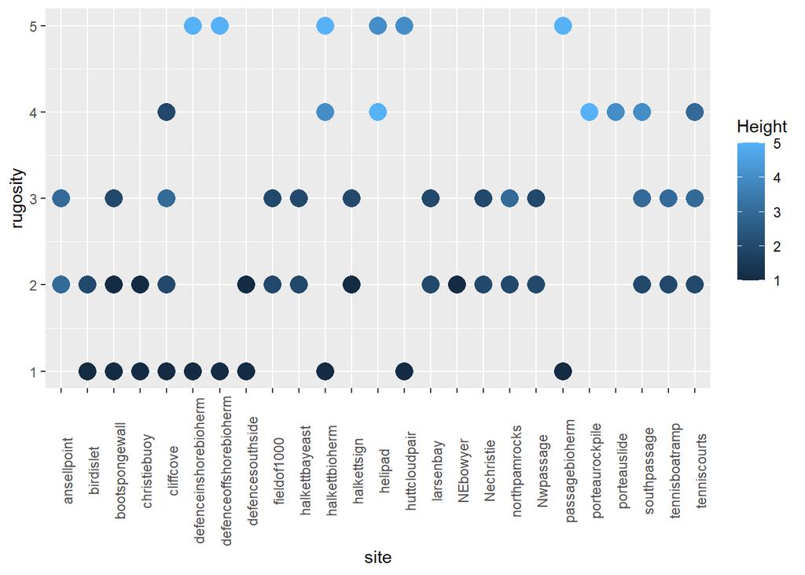

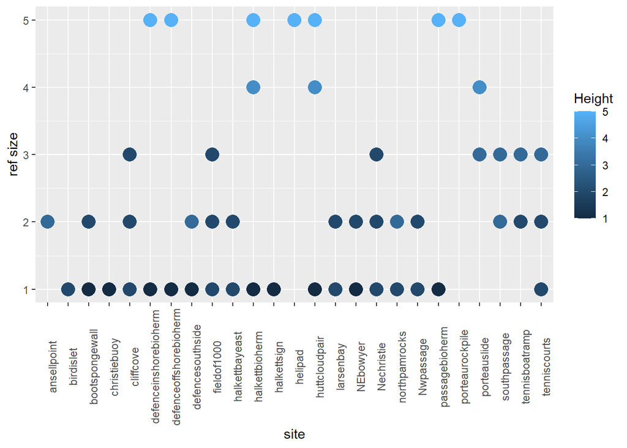

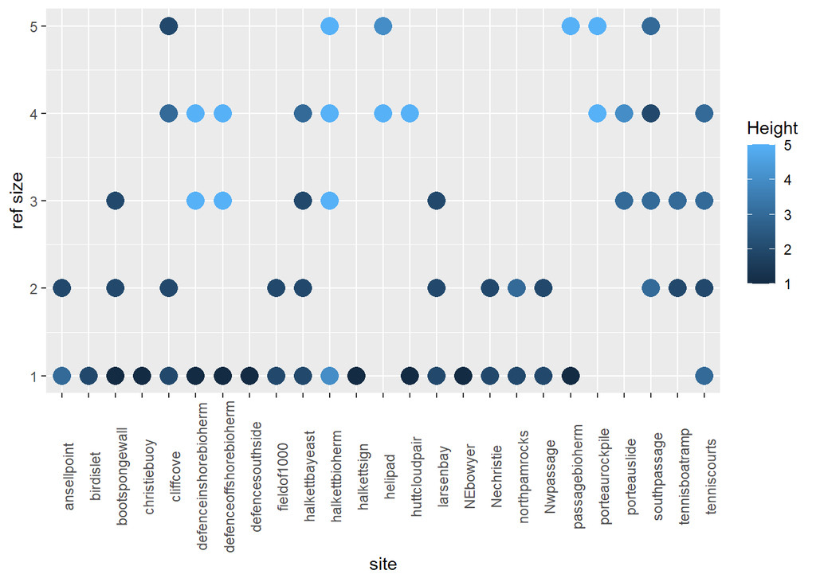

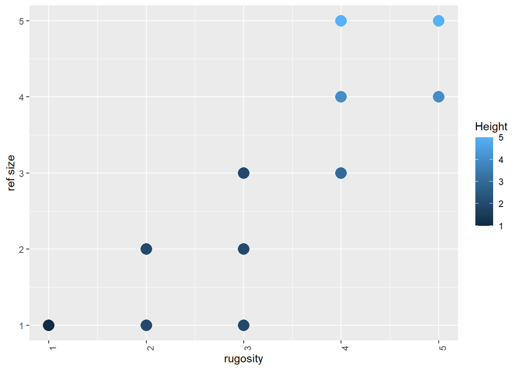

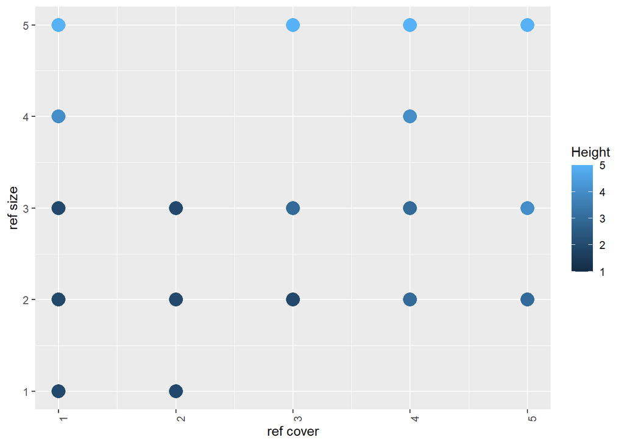

## A note on sponge gardens

We only had 3 potential gardens. One we removed because it was a boot sponge wall and the other complication was that the sponges at hutt pair were sliced off before the last sampling period.So I need to change the % cover info for that site for the last sample.

## Plots of habitat variables

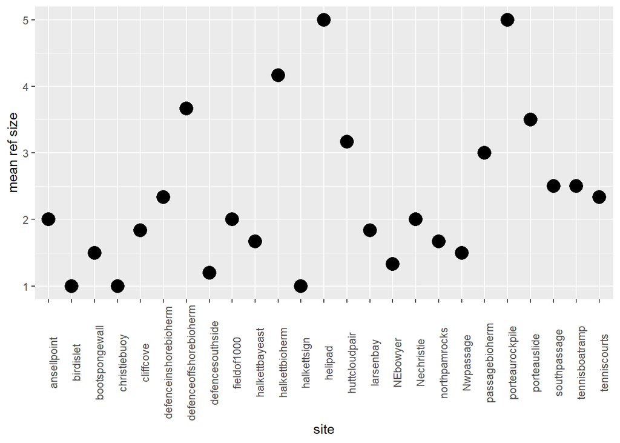

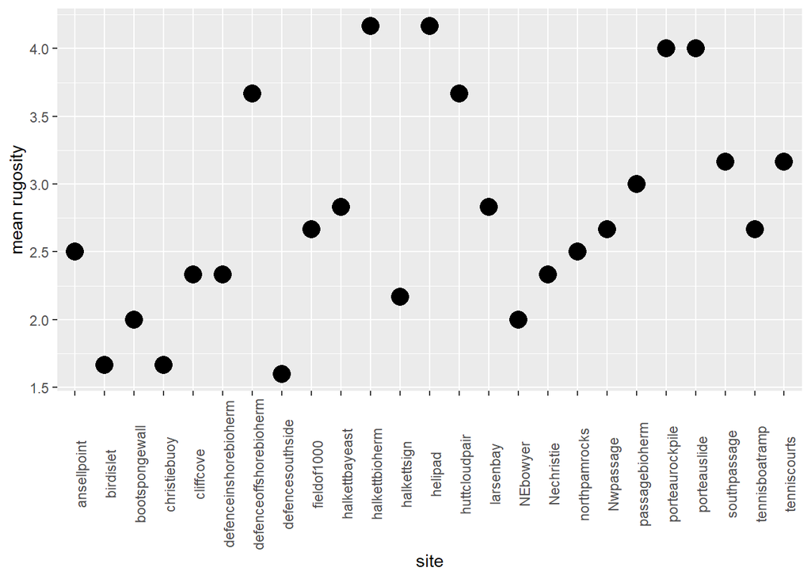

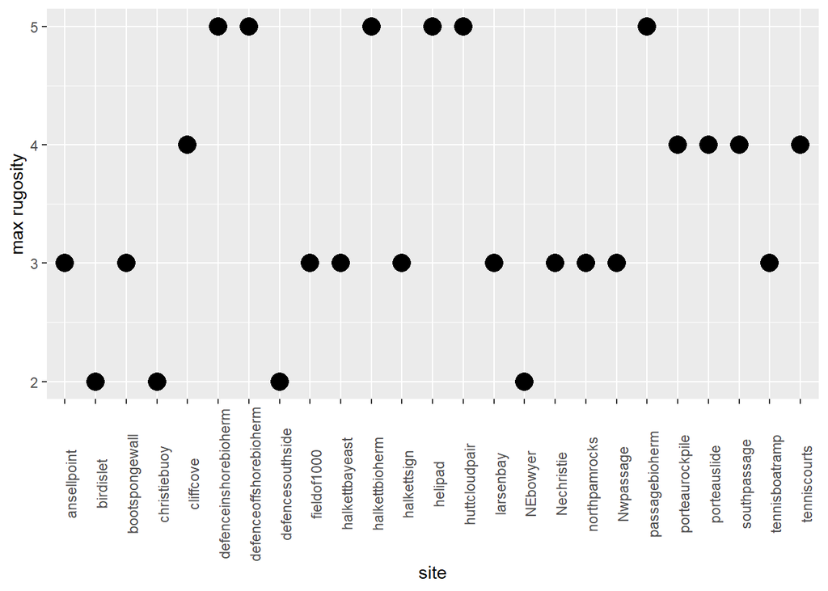

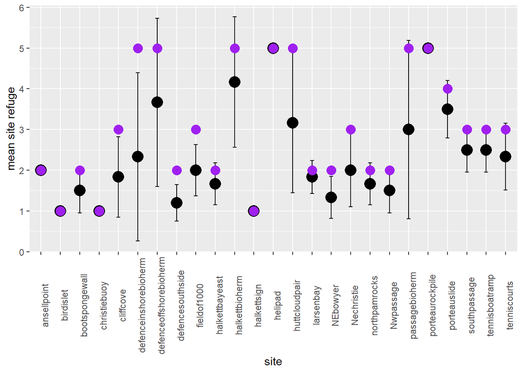

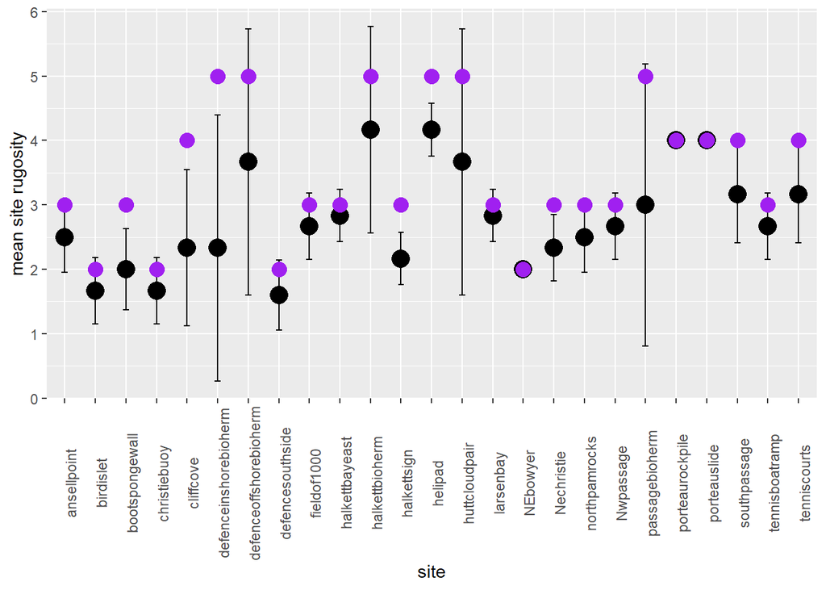

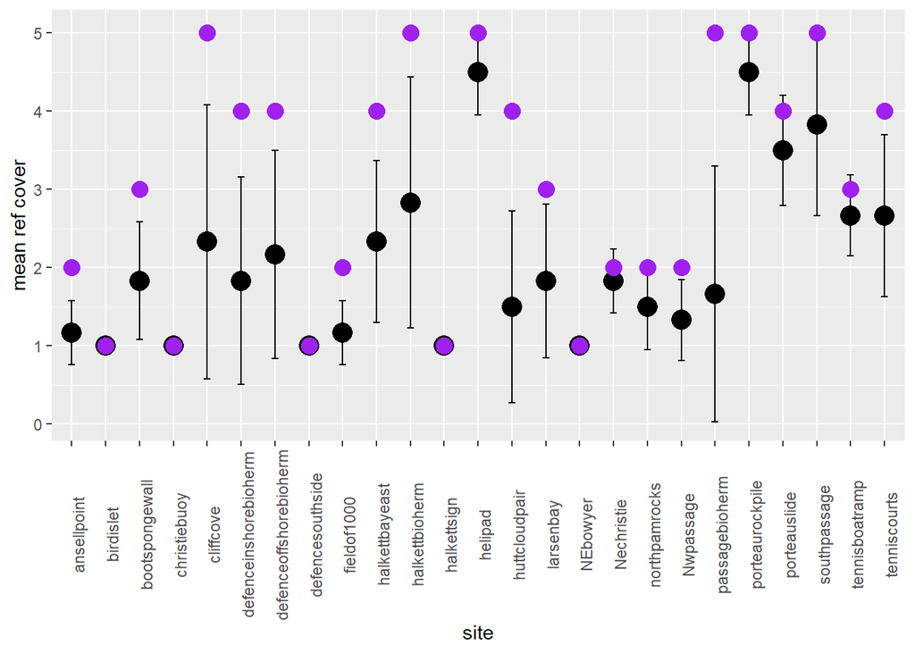

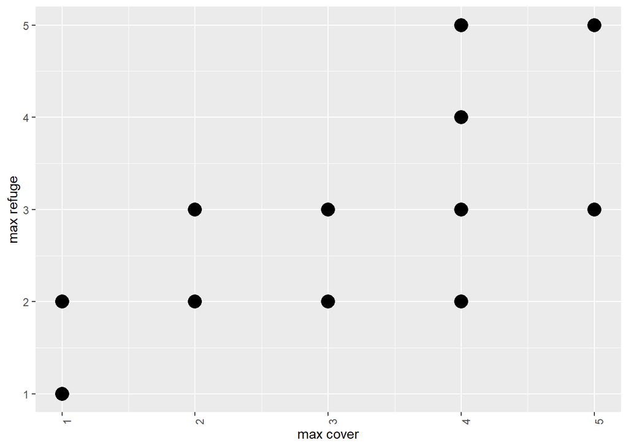

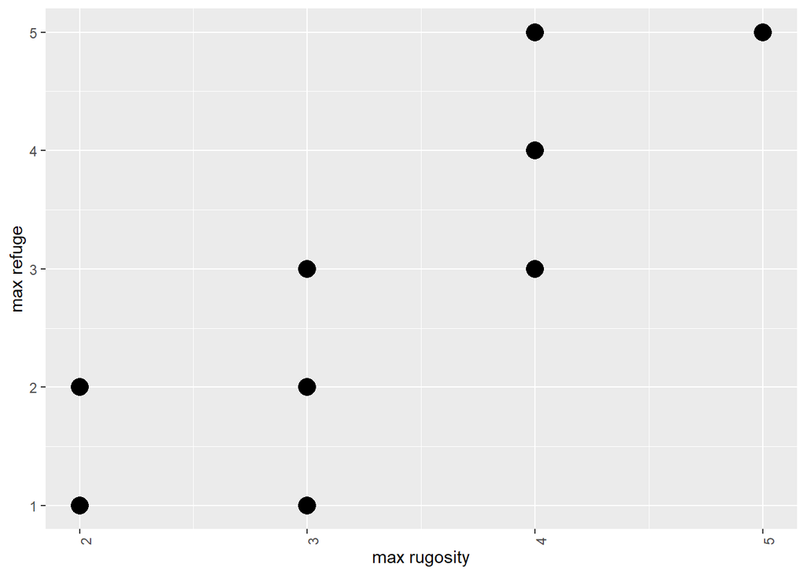

## Non-schooling rockfish models (no yellowtail)

Question 1. Does rockfish abundance differ between rocky reefs, sponge gardens and sponge reefs? (*Do we have enough data on sponge reefs? Should we add them to bioherms? rocky reefs? Hmmm question for discussion)

Could we include richness as a factor if we cant use it as a predictor variable?

```
## # A tibble: 37 × 33
## # Groups:   OpCode [37]
##    OpCode     richn…¹ Genus   Code Depth Date  habit…²  MaxN site  uniqu…³   lat
##    <fct>        <int> <fct>  <dbl> <dbl> <fct> <fct>   <dbl> <fct>   <dbl> <dbl>
##  1 birdislet…       1 Seba… 166726  21.8 9/6/… rocky …     2 bird…       4  49.4
##  2 birdislet…       1 Seba… 166726  26.8 11/2… rocky …     2 bird…       4  49.4
##  3 christieb…       2 Seba… 166726  20   10/1… rocky …     2 chri…      13  49.5
##  4 cliffcove…       3 Seba… 166713  26.8 11/1… rocky …     1 clif…      25  49.4
##  5 defencein…       2 Seba… 166713  23.1 9/12… sponge…     1 defe…       8  49.6
##  6 defencein…       1 Seba… 166726  25.3 10/3… sponge…     7 defe…       8  49.6
##  7 defencein…       2 Seba… 166713  25.2 11/1… sponge…     1 defe…       8  49.6
##  8 defenceof…       1 Seba… 166726  28.6 10/3… sponge…     5 defe…      23  49.6
##  9 defenceof…       1 Seba… 166726  28.7 11/1… sponge…     5 defe…      23  49.6
## 10 defenceso…       2 Seba… 166713  23.4 9/12… rocky …     2 defe…       9  49.6
## # … with 27 more rows, 22 more variables: lon <dbl>, temperature <dbl>,
## #   complexity1 <dbl>, complexity2 <dbl>, complexity3 <dbl>,
## #   current1.mpers <dbl>, current2.mpers <dbl>, current3.mpers <dbl>,
## #   mean.site.rug <dbl>, max.rug <dbl>, sd.site.rug <dbl>, mean.site.ref <dbl>,
## #   max.ref <dbl>, sd.site.ref <dbl>, mean.site.cov <dbl>, max.cov <dbl>,
## #   sd.site.cov <dbl>, sponge <fct>, complex <dbl>, current <dbl>, X <dbl>,
## #   Y <dbl>, and abbreviated variable names ¹richness, ²habitat_type, …
```

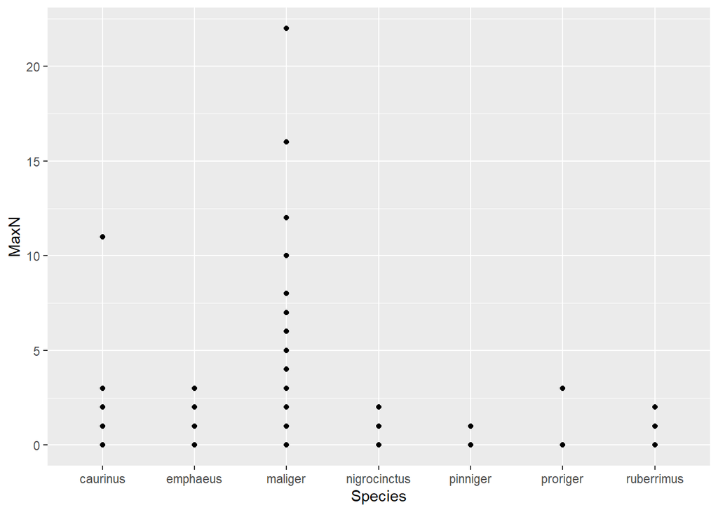

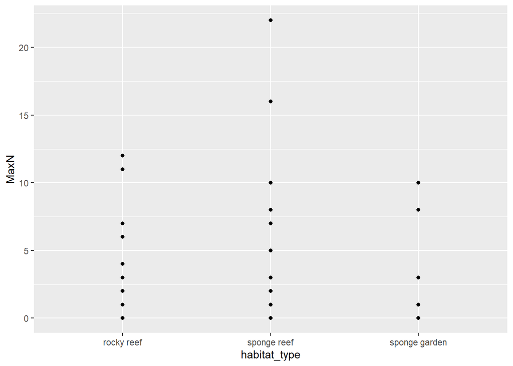

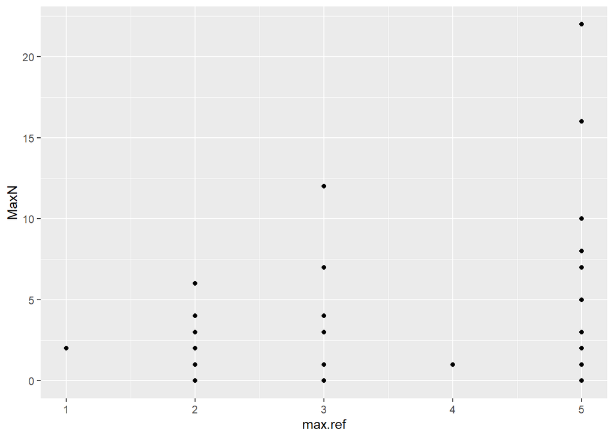

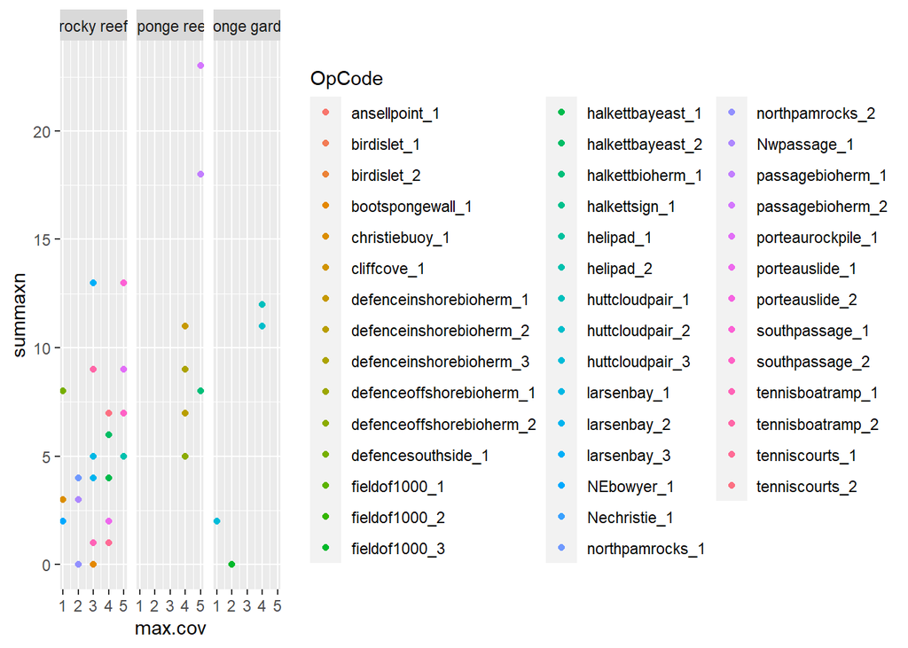

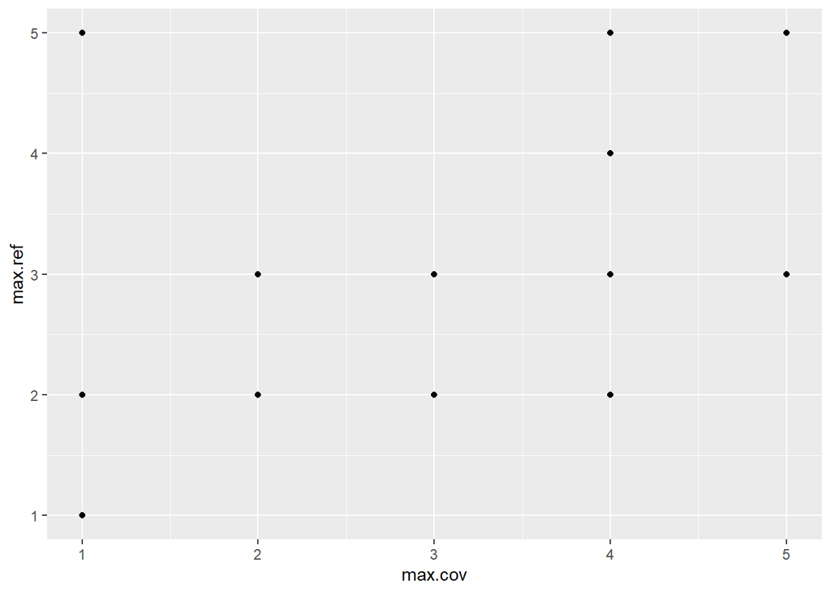

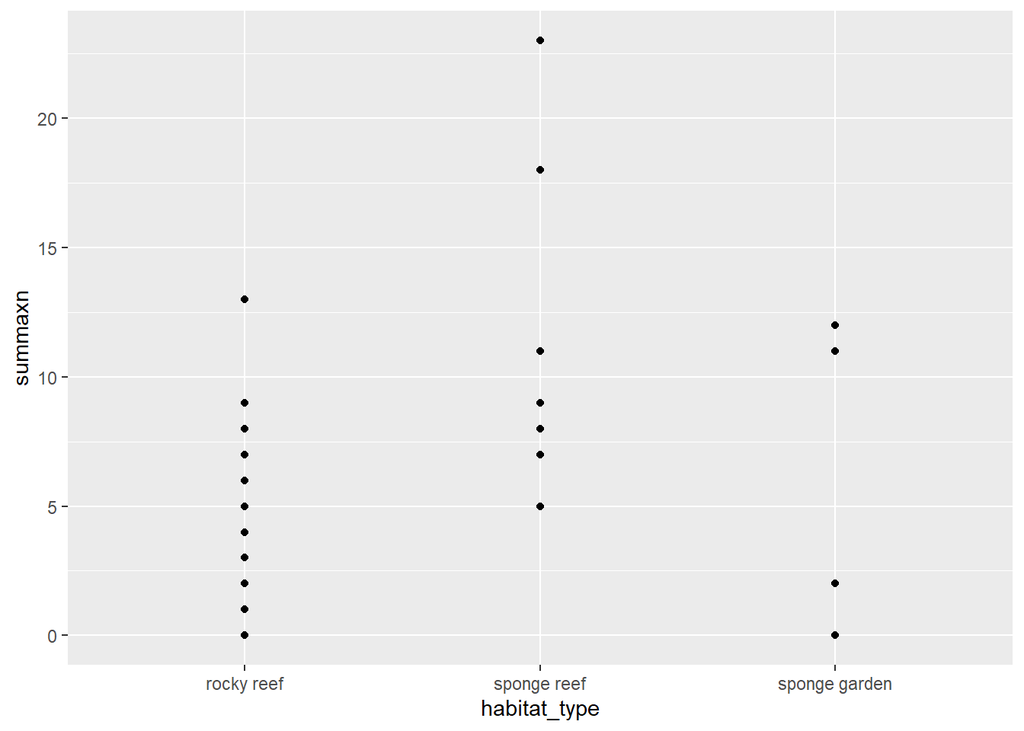

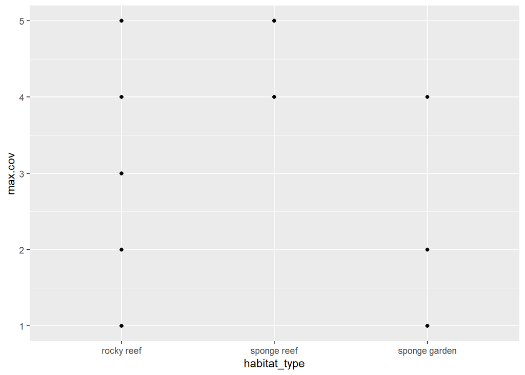

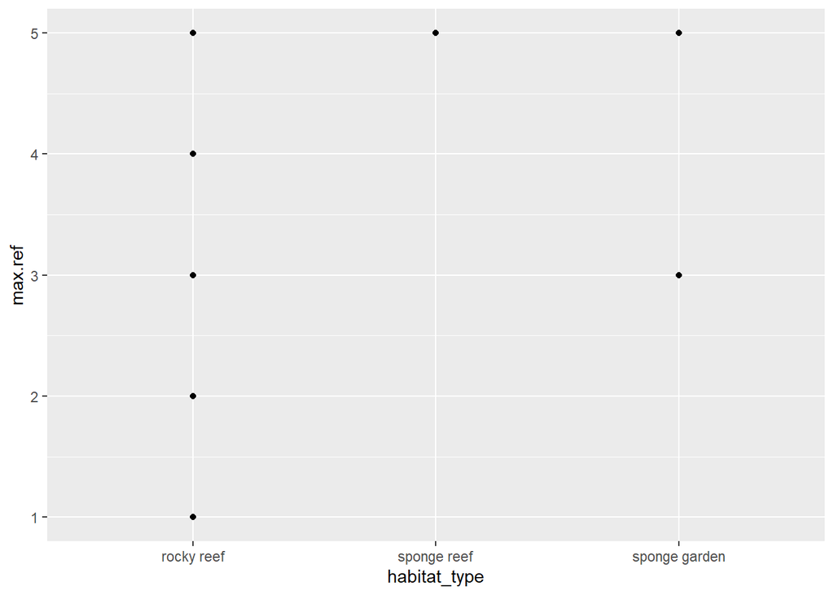

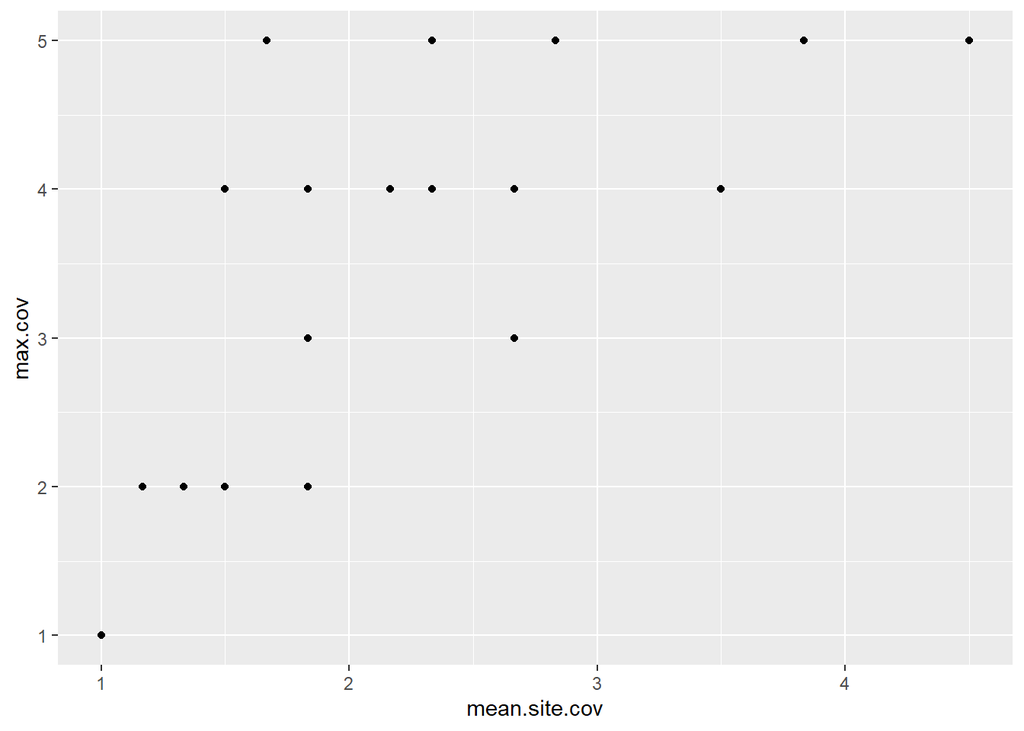

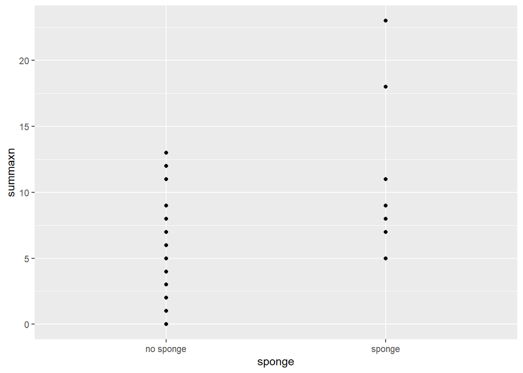

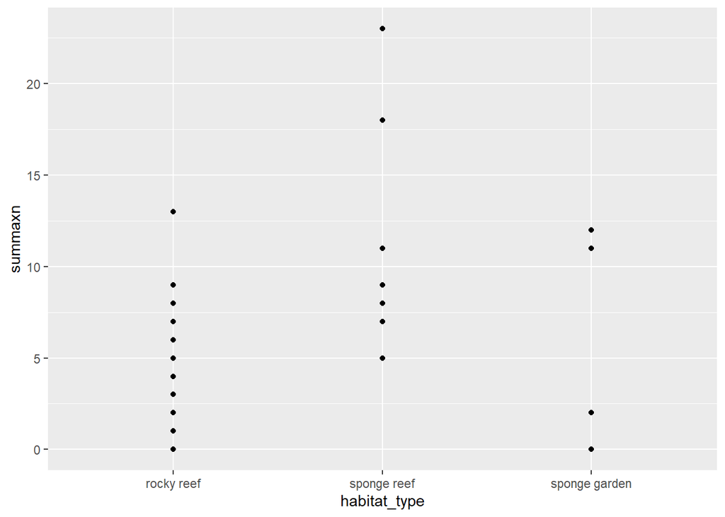

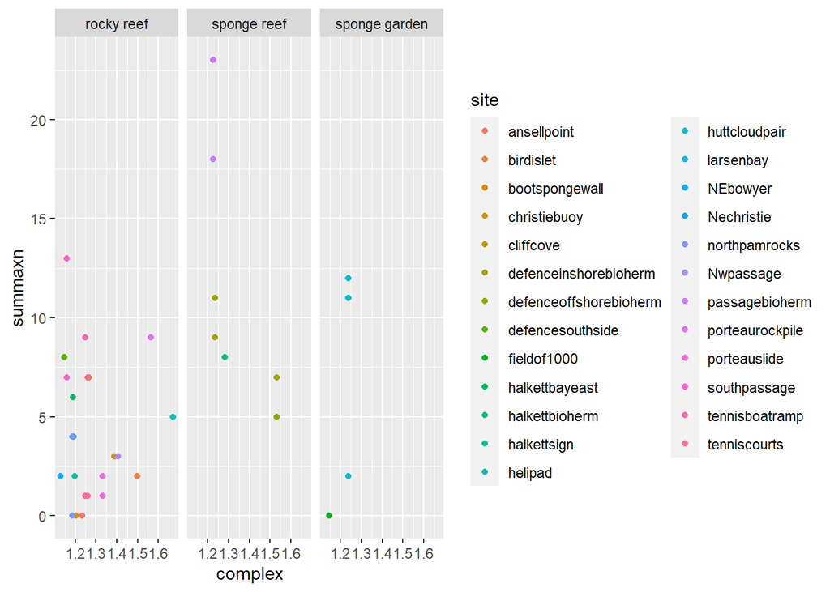

[2 more figures not shown]

Simple comparison between a NULL model and one with habitat type

```r
# Simple comparison between a NULL model and one with habitat type

null <- sdmTMB(formula = summaxn ~ 0 + (1|site), mesh = mesh, spatial = "off", family = tweedie(link = "log"),
            data = allrf, control = sdmTMBcontrol(newton_loops = 3))

hab1 <- sdmTMB(formula = summaxn ~ 0 + habitat_type + (1|site), mesh = mesh, spatial = "off", family = tweedie(link = "log"), data = allrf, control = sdmTMBcontrol(newton_loops = 3))

#two habitat categories
hab2 <- sdmTMB(formula = summaxn ~ 0 + sponge + (1|site), mesh = mesh, spatial = "off", family = tweedie(link = "log"), data = allrf, control = sdmTMBcontrol(newton_loops = 3))

AICtab(null, hab1)
```

```
##      dAIC df
## hab1  0.0 6
## null 24.8 3
```

```r
sanity(hab1)
```

```
## ✔ Non-linear minimizer suggests successful convergence
```

```
## ✔ Hessian matrix is positive definite
```

```
## ✔ No extreme or very small eigenvalues detected
```

```
## ✔ No gradients with respect to fixed effects are >= 0.001
```

```
## ✔ No fixed-effect standard errors are NA
```

```
## ✔ No standard errors look unreasonably large
```

```
## ✔ No sigma parameters are < 0.01
```

```
## ✔ No sigma parameters are > 100
```

```r
summary(hab1)
```

```
## Model fit by ML ['sdmTMB']
## Formula: summaxn ~ 0 + habitat_type + (1 | site)
## Mesh: mesh
## Data: allrf
## Family: tweedie(link = 'log')
##
##                           coef.est coef.se
## habitat_typerocky reef        1.36    0.19
## habitat_typesponge reef       2.27    0.31
## habitat_typesponge garden     1.16    0.51
##
## Random intercepts:
##      Std. Dev.
## site      0.49
##
## Dispersion parameter: 1.85
## Tweedie p: 1.12
## ML criterion at convergence: 112.078
##
## See ?tidy.sdmTMB to extract these values as a data frame.
```

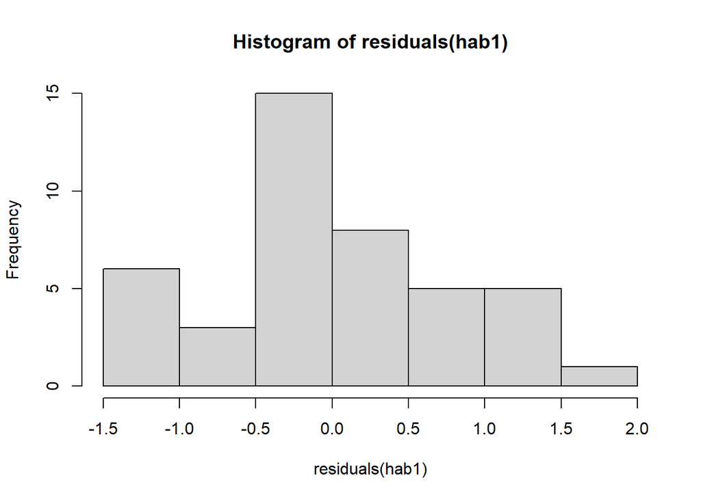

```r
hist(residuals(hab1))
```

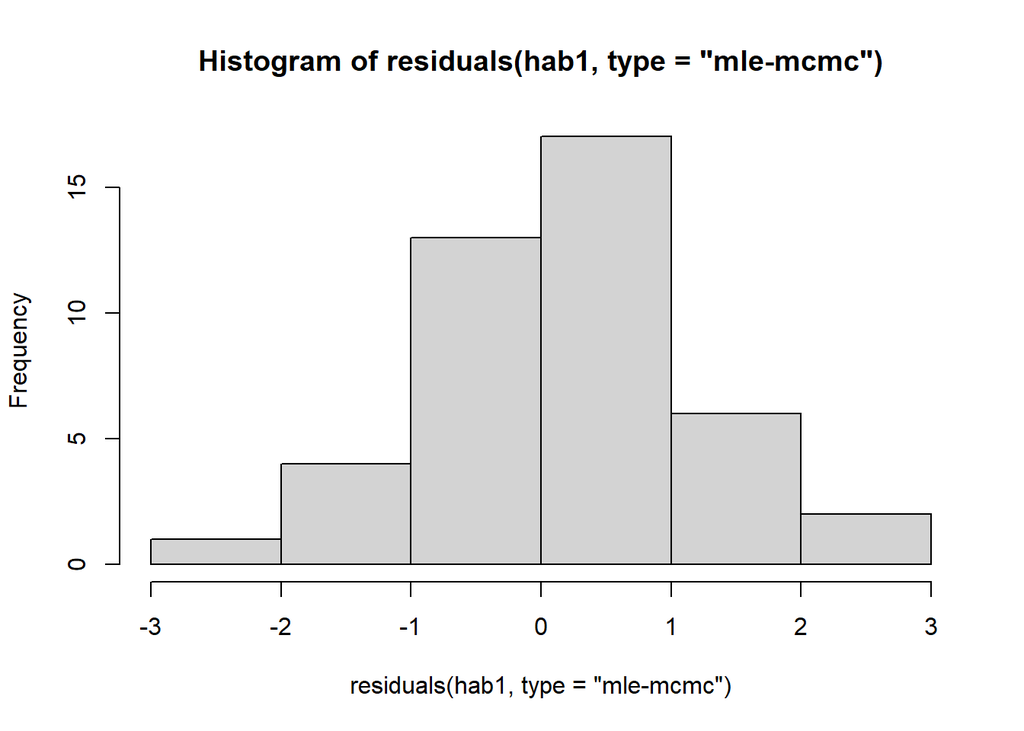

```r
hist(residuals(hab1, type = "mle-mcmc")) # another way to calculate them using mcmc, got from Philina's mesh building vignette
```

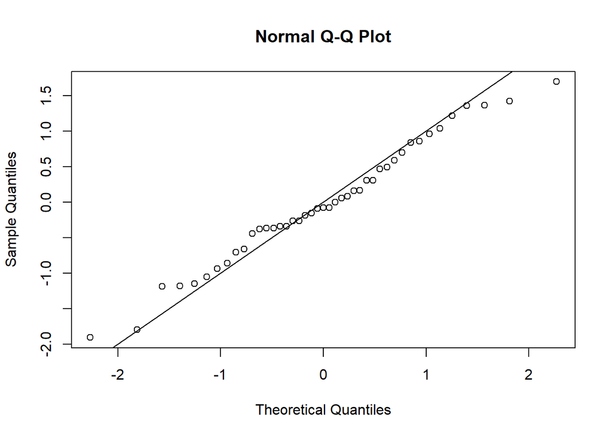

```r
qqnorm(residuals(hab1)) # qqnorm plot
abline(a = 0, b = 1) # add 1:1 line
```

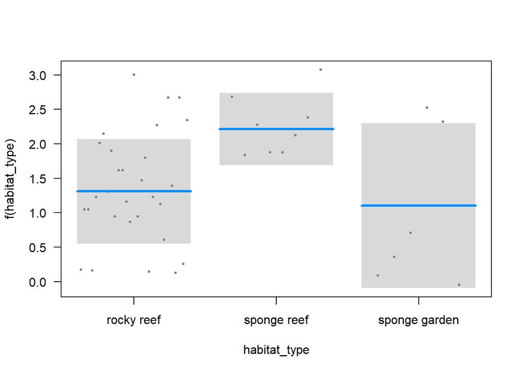

```r
visreg::visreg(hab1, "habitat_type")
```

## Discussion about what to do with sponge reefs?

```
## # A tibble: 3 × 10
##   OpCode mean.…¹ max.rug sd.si…² mean.…³ max.ref sd.si…⁴ mean.…⁵ max.cov sd.si…⁶
##   <fct>    <dbl>   <dbl>   <dbl>   <dbl>   <dbl>   <dbl>   <dbl>   <dbl>   <dbl>
## 1 huttc…    3.67       5    2.07    3.17       5    1.72     1.5       4    1.22
## 2 huttc…    3.67       5    2.07    3.17       5    1.72     1.5       4    1.22
## 3 huttc…    2.33       5    2.07    2          5    1.55     1         1    0
## # … with abbreviated variable names ¹mean.site.rug, ²sd.site.rug,
## #   ³mean.site.ref, ⁴sd.site.ref, ⁵mean.site.cov, ⁶sd.site.cov
```

### For example, if we combine the sponge gardens with the rocky reefs…

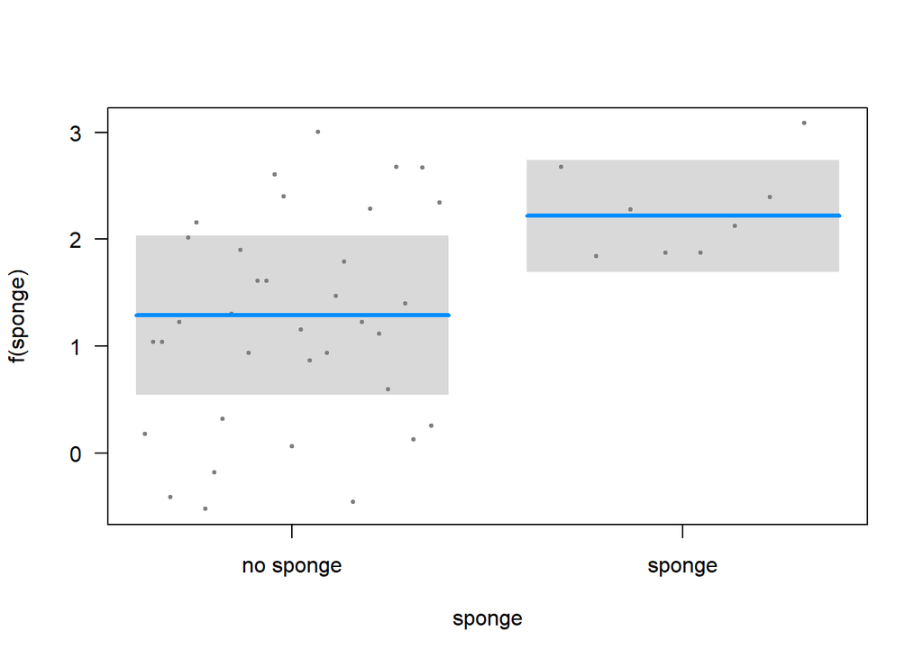

### Question 2. What are the main drivers of rockfish abundance

This question can be answered regardless of if there was a difference in habitat type or not. The metrics we have include max % cover of refuge (scale 1-5), max refuge size (scale 1-5), mean and SD of both of those metrics, depth, current (measured with flagging tape at time of deployment), complexity from SeaGIS analysis.

Okay shoot I completely forgot that larsen bay was missing complexity from the seaGIS measures and so I spent a while running this but I think because the n is lower it lowers the overall likihood because there were 40 measures with complexity not 43. Tested complexity on smaller dataset and now we are scrapping it

### model with max cover and mean site cover is lowest AIC but it is not fitting super well. Not sure why. It is model 16. model 2 is the one with just max cover and it fits well but has a difference of 2.4.

Also for model 16 the max cover and mean cover have opposite relationships….argh! Which maybe makes sense if the variability is super high? but then wouldn’t the SD be important?

```r
AICtab(m, m1, m2, m3, m4, m5, m6, m7, m8, m9)
```

```
##    dAIC df
## m2  0.0 4
## m9  0.8 4
## m5  4.2 4
## m3  7.9 4
## m8 10.3 4
## m6 12.0 4
## m1 12.2 6
## m4 15.3 4
## m7 17.4 4
## m  37.0 3
```

```r
AICtab(m, m1, m2, m3, m4, m5, m6, m7, m8, m9, m11, m12, m14, m15,m16, m17, m18,m19, m20, m21, m22)
```

```
##     dAIC df
## m16  0.0 5
## m20  1.6 6
## m17  2.1 5
## m2   2.4 4
## m9   3.2 4
## m14  3.8 5
## m15  3.9 5
## m21  4.0 8
## m12  6.0 7
## m5   6.6 4
## m22  7.9 8
## m3  10.3 4
## m19 11.4 5
## m11 12.2 7
## m18 12.3 5
## m8  12.7 4
## m6  14.4 4
## m1  14.6 6
## m4  17.8 4
## m7  19.8 4
## m   39.4 3
```

```r
tidy(m16, conf.int = TRUE)
```

```
## # A tibble: 2 × 5
##   term          estimate std.error conf.low conf.high
##   <chr>            <dbl>     <dbl>    <dbl>     <dbl>
## 1 max.cov          0.689    0.0750    0.542     0.836
## 2 mean.site.cov   -0.365    0.124    -0.608    -0.123
```

```r
sanity(m16) # a check from sdmTMB, not fitting well
```

```
## ✔ Non-linear minimizer suggests successful convergence
```

```
## ✔ Hessian matrix is positive definite
```

```
## ✔ No extreme or very small eigenvalues detected
```

```
## ✔ No gradients with respect to fixed effects are >= 0.001
```

```
## ✔ No fixed-effect standard errors are NA
```

```
## ✖ `ln_tau_G` standard error may be large
```

```
## ℹ `ln_tau_G` is an internal parameter affecting `sigma_G`
```

```
## ℹ `sigma_G` is the random intercept standard deviation
```

```
## ℹ Try simplifying the model, adjusting the mesh, or adding priors
```

```
## ✖ `sigma_G` is smaller than 0.01
```

```
## ℹ Consider omitting this part of the model
```

```r
sanity(m2) # a check from sdmTMB for the model with just max.cov
```

```
## ✔ Non-linear minimizer suggests successful convergence
```

```
## ✔ Hessian matrix is positive definite
```

```
## ✔ No extreme or very small eigenvalues detected
```

```
## ✔ No gradients with respect to fixed effects are >= 0.001
```

```
## ✔ No fixed-effect standard errors are NA
```

```
## ✔ No standard errors look unreasonably large
```

```
## ✔ No sigma parameters are < 0.01
```

```
## ✔ No sigma parameters are > 100
```

```r
tidy(m16, conf.int = TRUE)
```

```
## # A tibble: 2 × 5
##   term          estimate std.error conf.low conf.high
##   <chr>            <dbl>     <dbl>    <dbl>     <dbl>
## 1 max.cov          0.689    0.0750    0.542     0.836
## 2 mean.site.cov   -0.365    0.124    -0.608    -0.123
```

```r
tidy(m2, conf.int = TRUE)
```

```
## # A tibble: 1 × 5
##   term    estimate std.error conf.low conf.high
##   <chr>      <dbl>     <dbl>    <dbl>     <dbl>
## 1 max.cov    0.444    0.0375    0.370     0.517
```

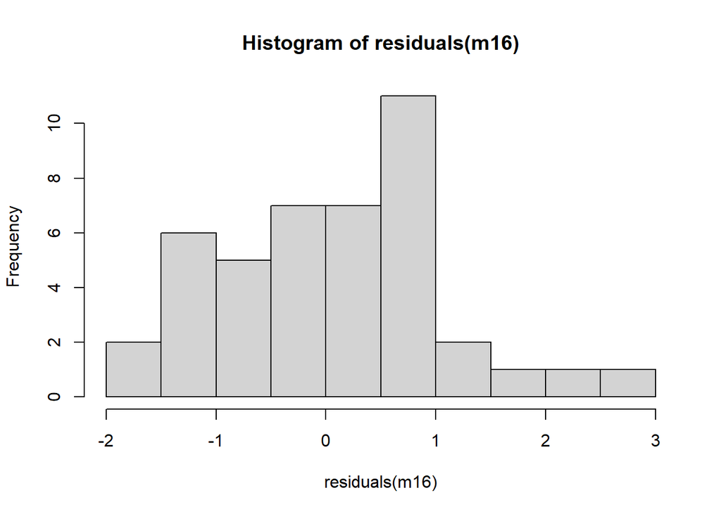

```r
hist(residuals(m16)) # look  at residuals
```

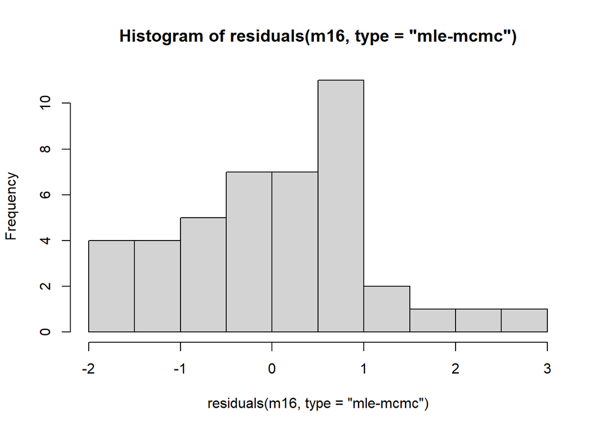

```r
hist(residuals(m16, type = "mle-mcmc")) # another way to calculate them using mcmc, got from Philina's mesh building vignette
```